# Introducción a la visualización de datos en R

### Cada `geom` puede tener su mapping

En realidad, en este caso, sería más útil tener una línea de regresión para todos los casos, no una para cada especie.

Aquí, es importante que entendamos que cada `geom` puede tener su mapping. En este caso, el mapping es casi idéntico para `geom_point` y para `geom_smooth.` La única diferencia es que en `geom_point` necesitamos indicar también qué variable tiene asignada el color.

Por lo tanto, una opción puede ser establecer los mappings compartidos al principio cuando llamamos a `ggplot()`, y luego añadir el mapping que necesitamos extra cuando llamamos a `geom_point``

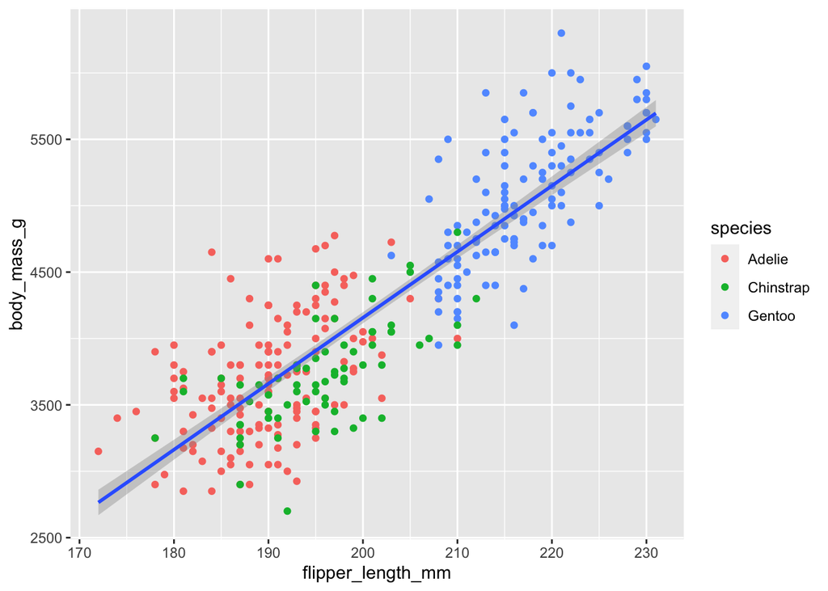

```r
ggplot(data = penguins,
       mapping = aes(x = flipper_length_mm,
                     y = body_mass_g)) +
  geom_point(mapping = aes(color = species)) +
  geom_smooth(method = "lm")
```

### Editando el texto de ejes, títulos, leyenda…

Una función muy útil dentro de `ggplot` es `labs()`. Busca la ayuda de esta función para ver qué parámetros tiene.

Intenta usar esos parámetros para editar el gráfico y que contenga el siguiente texto:

- Título: Masa corporal y longitud del pico
- Eje x: longitud del pico (mm)
- Eje y: Masa corporal (g)

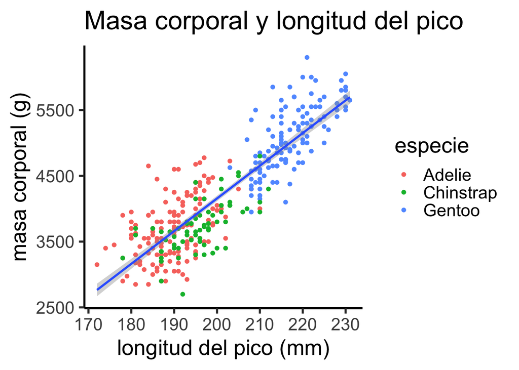

```r
ggplot(data = penguins,
       mapping = aes(x = flipper_length_mm,
                     y = body_mass_g)) +
  geom_point(aes(color = species)) +
  geom_smooth(method = "lm") +
  labs(
    title = "Masa corporal y longitud del pico",
    x = "longitud del pico (mm)",
    y = "masa corporal (g)",
    color = "especie"
  ) +
  theme_classic(base_size = 21)
```

## Visualizar más de un gráfico a la vez

Existen diferentes formas de visualizar más de un gráfico a la vez. Uno de los paquetes más versátiles y a la vez intuitivos es **`{patchwork}`**. Antes de empezar, asegúrate de que tienes este paquete instalado.

```r
#install.packages("patchwork")
library(patchwork)
```

Ahora, antes de nada, vamos a crear dos gráficos diferentes:

```r
plot_sex <- ggplot(data = penguins,
                   mapping = aes(x = species,
                                 color = sex,
                                 fill = sex)) +
  geom_bar(position="dodge")

plot_island <- ggplot(data = penguins,
                   mapping = aes(x = species,
                                 color = island,
                                 fill = island)) +
  geom_bar(position="dodge")
```

Ahora vamos a usar `{patchwork}` para visualizarlos a la vez.

Podemos poner un gráfico al lado del otro:

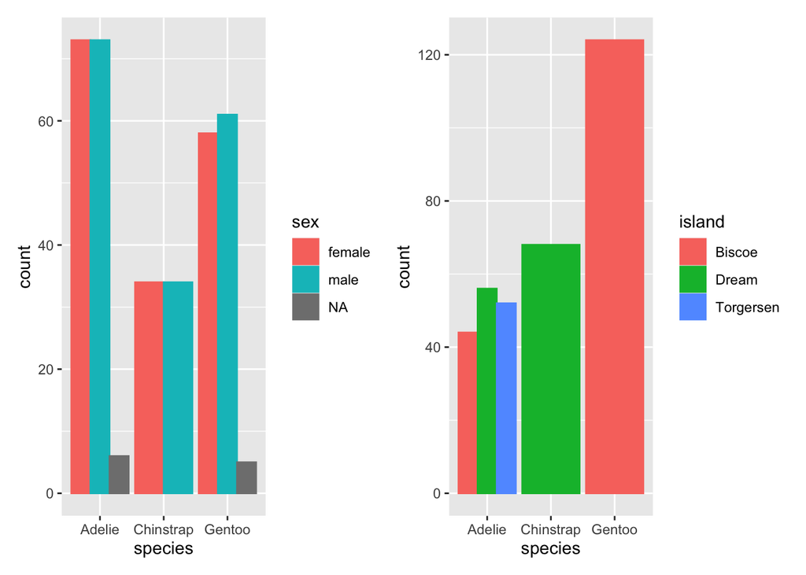

```r
library(patchwork)
plot_sex + plot_island # uno AL LADO del otro
```

O uno encima del otro:

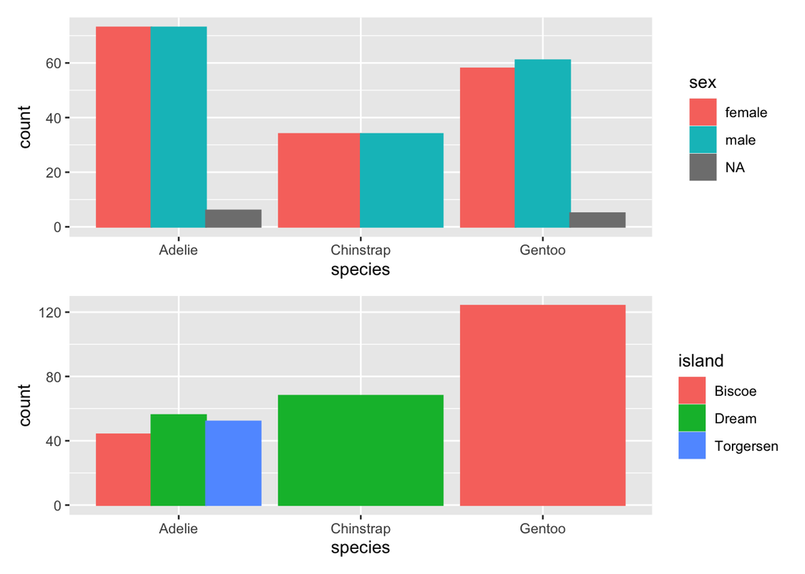

```r
plot_sex / plot_island # uno ENCIMA de otro
```

Si ahora creamos otra variable…

```r
scatter_size <- ggplot(data = penguins,
                      mapping = aes(x = flipper_length_mm,
                                    y = body_mass_g,
                                    color = island
                                    )
                ) +
  geom_point()
```

> 💡Podrías adiviar qué hace esta línea?

```
(plot_sex | plot_island) / scatter_size
```

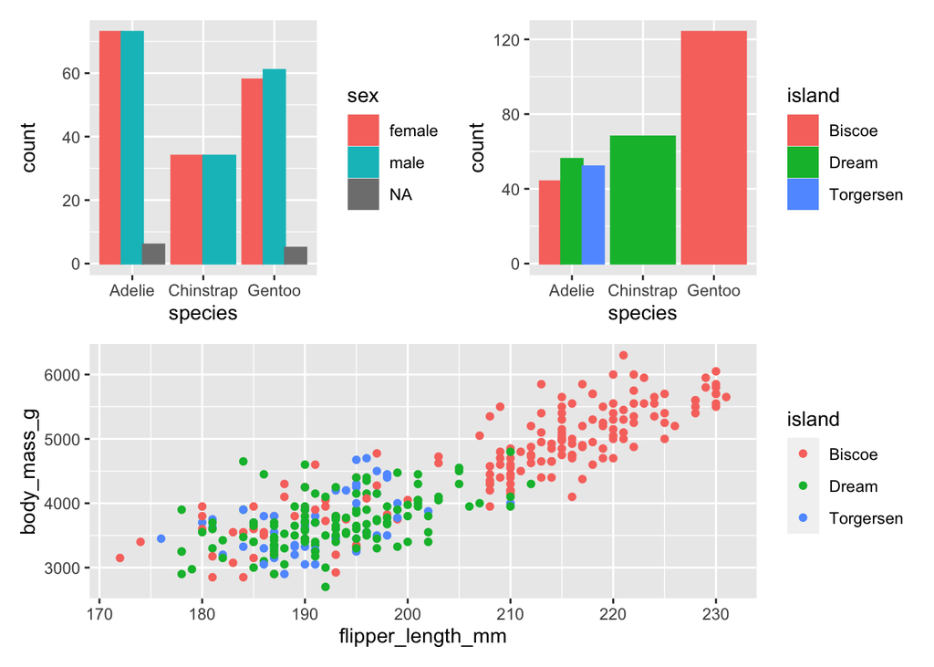

```r
(plot_sex | plot_island) / scatter_size
```

Con `{patchwork}`, podemos además, añadir etiquetas a nuestros gráficos

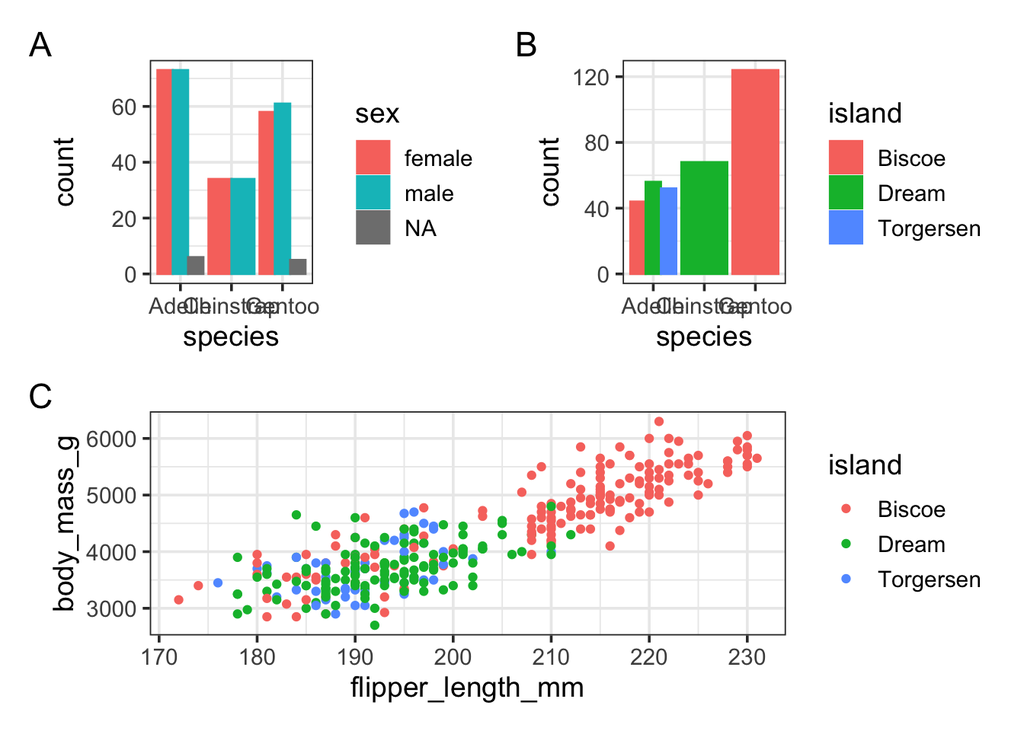

```r
figure <- (plot_sex | plot_island) / scatter_size

#figure + plot_annotation(tag_levels = 'A')

figure + plot_annotation(tag_levels = 'A') &
  theme_bw(base_size = 14)
```

Con **`{papaja}`** podemos aplicar directamente el estilo APA a un gráfico

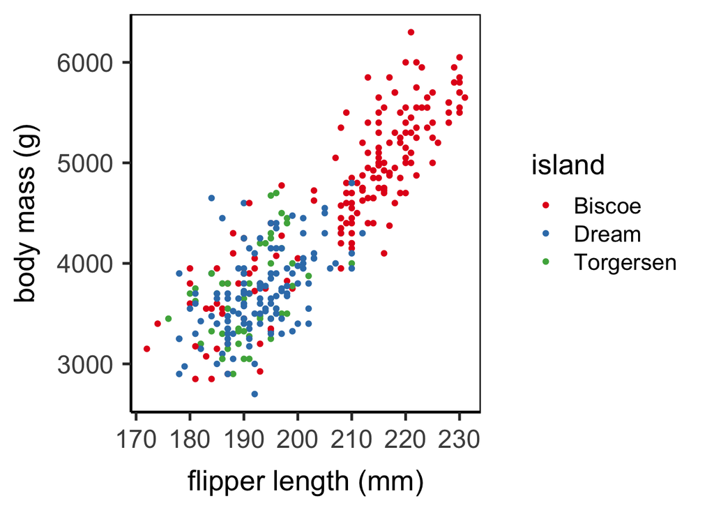

```r
#install.packages("papaja")
library(papaja)
scatter_size +
  scale_color_brewer(palette = "Set1") +
  labs(x = "flipper length (mm)",
       y = "body mass (g)",
  ) +
  theme_apa(box = TRUE, base_size = 20)
```

Además, `{papaja}` contiene varias funciones que son útiles para preparar nuestros outputs de R para manuscritos. Por ejemplo, la función `apa_table` convierte tablas al formato APA.

Podemos imprimir solo la tabla:

```r
apa_table(head(penguins))
```

(#tab:table)

| species | island | bill_length_mm | bill_depth_mm | flipper_length_mm | body_mass_g | sex | year |
| --- | --- | --- | --- | --- | --- | --- | --- |
| Adelie | Torgersen | 39.10 | 18.70 | 181 | 3750 | male | 2007 |
| Adelie | Torgersen | 39.50 | 17.40 | 186 | 3800 | female | 2007 |
| Adelie | Torgersen | 40.30 | 18.00 | 195 | 3250 | female | 2007 |
| Adelie | Torgersen | NA | NA | NA | NA | NA | 2007 |
| Adelie | Torgersen | 36.70 | 19.30 | 193 | 3450 | female | 2007 |
| Adelie | Torgersen | 39.30 | 20.60 | 190 | 3650 | male | 2007 |

O imprimirla directamente con un formato que respeta las normas APA:

```r
apa_table(
  head(penguins)
  , caption = "Table 1"
  , note = "First few rows of the *palmerpenguin* dataset."
  , escape = TRUE
)
```

(#tab:table-full) Table 1

| species | island | bill_length_mm | bill_depth_mm | flipper_length_mm | body_mass_g | sex | year |
| --- | --- | --- | --- | --- | --- | --- | --- |
| Adelie | Torgersen | 39.10 | 18.70 | 181 | 3750 | male | 2007 |
| Adelie | Torgersen | 39.50 | 17.40 | 186 | 3800 | female | 2007 |
| Adelie | Torgersen | 40.30 | 18.00 | 195 | 3250 | female | 2007 |
| Adelie | Torgersen | NA | NA | NA | NA | NA | 2007 |
| Adelie | Torgersen | 36.70 | 19.30 | 193 | 3450 | female | 2007 |
| Adelie | Torgersen | 39.30 | 20.60 | 190 | 3650 | male | 2007 |

*Note.* First few rows of the *palmerpenguin* dataset.

También podemos crear tablas de mensajes más complejos como el output de una regresión:

```r
lm_out <- lm(data = penguins, formula = bill_length_mm ~ bill_depth_mm + flipper_length_mm)
summary(lm_out)
```

```
##
## Call:
## lm(formula = bill_length_mm ~ bill_depth_mm + flipper_length_mm,
##     data = penguins)
##
## Residuals:
##      Min       1Q   Median       3Q      Max
## -10.8831  -2.7734  -0.3268   2.3128  19.7630
##
## Coefficients:
##                    Estimate Std. Error t value Pr(>|t|)
## (Intercept)       -28.14701    5.51435  -5.104 5.54e-07 ***
## bill_depth_mm       0.62103    0.13543   4.586 6.38e-06 ***
## flipper_length_mm   0.30569    0.01902  16.073  < 2e-16 ***
## ---
## Signif. codes:  0 '***' 0.001 '**' 0.01 '*' 0.05 '.' 0.1 ' ' 1
##
## Residual standard error: 4.009 on 339 degrees of freedom
##   (2 observations deleted due to missingness)
## Multiple R-squared:  0.4638, Adjusted R-squared:  0.4607
## F-statistic: 146.6 on 2 and 339 DF,  p-value: < 2.2e-16
```

```r
apa_lm <- apa_print(lm_out)
apa_table(
  apa_lm$table
  , caption = "A full regression table."
)
```

(#tab:unnamed-chunk-11) A full regression table.

| Predictor | $b$ | 95% CI | $t$ | $\mathit{df}$ | $p$ |
| --- | --- | --- | --- | --- | --- |
| Intercept | -28.15 | [-38.99, -17.30] | -5.10 | 339 | < .001 |
| Bill depth mm | 0.62 | [0.35, 0.89] | 4.59 | 339 | < .001 |
| Flipper length mm | 0.31 | [0.27, 0.34] | 16.07 | 339 | < .001 |

```r
apa_lm$table
```

| term | estimate | conf.int | statistic | df | p.value |
| --- | --- | --- | --- | --- | --- |
| Intercept | -28.15 | [-38.99, -17.30] | -5.10 | 339 | < .001 |
| Bill depth mm | 0.62 | [0.35, 0.89] | 4.59 | 339 | < .001 |
| Flipper length mm | 0.31 | [0.27, 0.34] | 16.07 | 339 | < .001 |

O de un ANOVA:

```r
anova_result <- aov(bill_length_mm ~ species, data = penguins)

apa_anova <- apa_print(summary(anova_result))
```

```
## For one-way between subjects designs, generalized eta squared is
##   equivalent to eta squared. Returning eta squared.
```

```r
apa_table(
  apa_anova
  , caption = "A full regression table."
)
```

(#tab:unnamed-chunk-12) A full regression table.

| Effect | $\hat{\eta}^2_G$ | 90% CI | $F$ | $\mathit{df}$ | $\mathit{df}_{\mathrm{res}}$ | $p$ |
| --- | --- | --- | --- | --- | --- | --- |
| Species | .708 | [.669, .740] | 410.60 | 2 | 339 | < .001 |

El output de `apa_table` es útil si queremos tener la tabla en formato APA en nuestro reporte de R Markdown. Sin embargo, no es tan útil si queremos el resultado en un word directamente.

Para ello, podemos usar, por ejemplo, el paquete **`{apaTables}`** para guardar nuestra tabla en formato .doc:

```r
#install.packages("apaTables",dep=T)
library(apaTables)

table <- apa.aov.table(anova_result, filename = "tablas/anova_table.doc")

table <- apa.reg.table(lm_out, filename = "tablas/regression_table.doc")
```